# Getting Started With the COVID-19 Data: Clustering

Michael Hahsler

2021-03-17

I use mostly tidyverse and ggplot. The focus of the analysis is Texas and Dallas County, TX.

```r
library("tidyverse")
```

```r
library("ggplot2")
library("DT")
```

# Prepare COVID 19 Cases in Texas Counties

https://console.cloud.google.com/marketplace/details/usafacts-public-data/covid19-us-cases?filter=solution-type:dataset&filter=category:covid19&id=3eaff9c5-fbaf-47bb-a441-89db1e1395ab

using the query

> ```
> SELECT *
> FROM `bigquery-public-data.covid19_usafacts.summary` covid19
> JOIN `bigquery-public-data.census_bureau_acs.county_2017_5yr` acs
> ON covid19.county_fips_code = acs.geo_id
> WHERE date = DATE_SUB(CURRENT_DATE(), INTERVAL 7 day)
> ```

**You will need newer data and probably also trend variables (change during the last week)**

```r
cases <- read_csv("COVID-19_cases_plus_census.csv")
cases
```

```
## # A tibble: 3,142 x 259
##    county_fips_code county_name state state_fips_code date       confirmed_cases
##    <chr>            <chr>       <chr> <chr>           <date>               <dbl>
##  1 50009            Essex Coun… VT    50              2021-01-19             111
##  2 50007            Chittenden… VT    50              2021-01-19            3636
##  3 10001            Kent County DE    10              2021-01-19           11548
##  4 44009            Washington… RI    44              2021-01-19            5521
##  5 33001            Belknap Co… NH    33              2021-01-19            2496
##  6 44005            Newport Co… RI    44              2021-01-19            3578
##  7 50015            Lamoille C… VT    50              2021-01-19             312
##  8 09013            Tolland Co… CT    09              2021-01-19            6255
##  9 50001            Addison Co… VT    50              2021-01-19             527
## 10 50005            Caledonia … VT    50              2021-01-19             307
## # … with 3,132 more rows, and 253 more variables: deaths <dbl>, geo_id <chr>,
## #   nonfamily_households <dbl>, family_households <dbl>,
## #   median_year_structure_built <dbl>, rent_burden_not_computed <dbl>,
## #   rent_over_50_percent <dbl>, rent_40_to_50_percent <dbl>,
## #   rent_35_to_40_percent <dbl>, rent_30_to_35_percent <dbl>,
## #   rent_25_to_30_percent <dbl>, rent_20_to_25_percent <dbl>,
## #   rent_15_to_20_percent <dbl>, rent_10_to_15_percent <dbl>,
## #   rent_under_10_percent <dbl>, total_pop <dbl>, male_pop <dbl>,
## #   female_pop <dbl>, median_age <dbl>, white_pop <dbl>, black_pop <dbl>,
## #   asian_pop <dbl>, hispanic_pop <dbl>, amerindian_pop <dbl>,
## #   other_race_pop <dbl>, two_or_more_races_pop <dbl>, not_hispanic_pop <dbl>,
## #   commuters_by_public_transportation <dbl>, households <dbl>,
## #   median_income <dbl>, income_per_capita <dbl>, housing_units <dbl>,
## #   vacant_housing_units <dbl>, vacant_housing_units_for_rent <dbl>,
## #   vacant_housing_units_for_sale <dbl>, median_rent <dbl>,
## #   percent_income_spent_on_rent <dbl>, owner_occupied_housing_units <dbl>,
## #   million_dollar_housing_units <dbl>, mortgaged_housing_units <dbl>,
## #   families_with_young_children <dbl>,
## #   two_parent_families_with_young_children <dbl>,
## #   two_parents_in_labor_force_families_with_young_children <dbl>,
## #   two_parents_father_in_labor_force_families_with_young_children <dbl>,
## #   two_parents_mother_in_labor_force_families_with_young_children <dbl>,
## #   two_parents_not_in_labor_force_families_with_young_children <dbl>,
## #   one_parent_families_with_young_children <dbl>,
## #   father_one_parent_families_with_young_children <dbl>,
## #   father_in_labor_force_one_parent_families_with_young_children <dbl>,
## #   commute_10_14_mins <dbl>, commute_15_19_mins <dbl>,
```

[output cut: 10 more lines]

```
## #   income_200000_or_more <dbl>,
## #   renter_occupied_housing_units_paying_cash_median_gross_rent <dbl>,
## #   owner_occupied_housing_units_lower_value_quartile <dbl>,
## #   owner_occupied_housing_units_median_value <dbl>,
## #   owner_occupied_housing_units_upper_value_quartile <dbl>,
## #   married_households <dbl>, occupied_housing_units <dbl>,
## #   housing_units_renter_occupied <dbl>, dwellings_1_units_detached <dbl>,
## #   dwellings_1_units_attached <dbl>, dwellings_2_units <dbl>,
## #   dwellings_3_to_4_units <dbl>, dwellings_5_to_9_units <dbl>,
## #   dwellings_10_to_19_units <dbl>, dwellings_20_to_49_units <dbl>,
## #   dwellings_50_or_more_units <dbl>, mobile_homes <dbl>,
## #   housing_built_2005_or_later <dbl>, housing_built_2000_to_2004 <dbl>,
## #   housing_built_1939_or_earlier <dbl>, male_under_5 <dbl>, male_5_to_9 <dbl>,
## #   male_10_to_14 <dbl>, male_15_to_17 <dbl>, male_18_to_19 <dbl>,
## #   male_20 <dbl>, male_21 <dbl>, male_22_to_24 <dbl>, male_25_to_29 <dbl>, …
```

Make character factors for analysis

```r
cases <- cases %>% mutate_if(is.character, factor)
dim(cases)
```

```
## [1] 3142  259
```

Filter Texas

```r
cases_TX <- cases %>% filter(state == "TX")
dim(cases_TX)
```

```
## [1] 254 259
```

```r
summary(cases_TX[,1:10])
```

```
##  county_fips_code           county_name      state     state_fips_code
##  48001  :  1      Anderson County :  1   TX     :254   48     :254
##  48003  :  1      Andrews County  :  1   AK     :  0   01     :  0
##  48005  :  1      Angelina County :  1   AL     :  0   02     :  0
##  48007  :  1      Aransas County  :  1   AR     :  0   04     :  0
##  48009  :  1      Archer County   :  1   AZ     :  0   05     :  0
##  48011  :  1      Armstrong County:  1   CA     :  0   06     :  0
##  (Other):248      (Other)         :248   (Other):  0   (Other):  0
##       date            confirmed_cases      deaths            geo_id
##  Min.   :2021-01-19   Min.   :     1   Min.   :   0.00   48001  :  1
##  1st Qu.:2021-01-19   1st Qu.:   487   1st Qu.:  13.00   48003  :  1
##  Median :2021-01-19   Median :  1310   Median :  30.00   48005  :  1
##  Mean   :2021-01-19   Mean   :  8419   Mean   : 127.48   48007  :  1
##  3rd Qu.:2021-01-19   3rd Qu.:  3502   3rd Qu.:  78.75   48009  :  1
##  Max.   :2021-01-19   Max.   :286356   Max.   :3825.00   48011  :  1
##                                                          (Other):248
##  nonfamily_households family_households
##  Min.   :    12       Min.   :     19
##  1st Qu.:   674       1st Qu.:   1618
##  Median :  1883       Median :   4474
##  Mean   : 11300       Mean   :  25828
##  3rd Qu.:  4683       3rd Qu.:  12366
##  Max.   :496164       Max.   :1066649
##
```

Calculate rates (per 1000 people) and select important variables. **You need more variables**.

```r
cases_TX <- cases_TX %>%
  filter(confirmed_cases > 100) %>%
  arrange(desc(confirmed_cases)) %>%
  select(county_name, confirmed_cases, deaths, total_pop, median_income, median_age, poverty, commuters_by_public_transportation)
cases_TX <- cases_TX %>% mutate(
  cases_per_1000 = confirmed_cases/total_pop*1000,
  deaths_per_1000 = deaths/total_pop*1000,
  death_per_case = deaths/confirmed_cases)

summary(cases_TX)
```

```
##            county_name  confirmed_cases      deaths          total_pop
##  Anderson County :  1   Min.   :   114   Min.   :   1.00   Min.   :   1084
##  Andrews County  :  1   1st Qu.:   568   1st Qu.:  15.75   1st Qu.:   8082
##  Angelina County :  1   Median :  1412   Median :  32.50   Median :  20082
##  Aransas County  :  1   Mean   :  8907   Mean   : 134.80   Mean   : 114196
##  Archer County   :  1   3rd Qu.:  4109   3rd Qu.:  84.00   3rd Qu.:  53171
##  Armstrong County:  1   Max.   :286356   Max.   :3825.00   Max.   :4525519
##  (Other)         :234
##  median_income     median_age       poverty
##  Min.   :24794   Min.   :25.80   Min.   :   140
##  1st Qu.:42354   1st Qu.:34.60   1st Qu.:  1290
##  Median :47922   Median :38.35   Median :  3072
##  Mean   :49575   Mean   :38.81   Mean   : 17874
##  3rd Qu.:54971   3rd Qu.:42.90   3rd Qu.:  8134
##  Max.   :93645   Max.   :57.10   Max.   :751985
##
##  commuters_by_public_transportation cases_per_1000   deaths_per_1000
##  Min.   :    0.0                    Min.   : 23.11   Min.   :0.2987
##  1st Qu.:    0.0                    1st Qu.: 59.43   1st Qu.:1.2191
##  Median :   12.0                    Median : 75.75   Median :1.7347
##  Mean   :  780.4                    Mean   : 78.86   Mean   :1.8489
##  3rd Qu.:   59.0                    3rd Qu.: 94.24   3rd Qu.:2.3794
##  Max.   :57933.0                    Max.   :182.90   Max.   :5.4608
##
##  death_per_case
##  Min.   :0.003789
##  1st Qu.:0.015399
##  Median :0.022840
##  Mean   :0.024447
##  3rd Qu.:0.030473
##  Max.   :0.093220
##
```

Looks like there are no missing values to deal with.

# My Data Table

This is the cleaned data I use for analysis.

```r
datatable(cases_TX) %>% formatRound(c(5, 9, 10), 2) %>% formatPercentage(11, 2)
```

|  | county_name | confirmed_cases | deaths | total_pop | median_income | median_age | poverty | commuters_by_public_transportation | cases_per_1000 | deaths_per_1000 | death_per_case |
| --- | --- | --- | --- | --- | --- | --- | --- | --- | --- | --- | --- |
| 1 | Harris County | 286356 | 3825 | 4525519 | 57791 | 33.1 | 751985 | 57933 | 63.2758364289267 | 0.845206925437723 | 0.0133574990571177 |
| 2 | Dallas County | 234625 | 2453 | 2552213 | 53626 | 33.3 | 446611 | 34917 | 91.9300230819293 | 0.961126677122952 | 0.0104549813532232 |
| 3 | Tarrant County | 195518 | 1798 | 1983675 | 62532 | 34.2 | 264575 | 5669 | 98.5635247709428 | 0.906398477573191 | 0.00919608424799763 |
| 4 | Bexar County | 152231 | 2040 | 1892004 | 53999 | 33.3 | 304792 | 22716 | 80.4601893019254 | 1.07822182194118 | 0.0134006871136628 |
| 5 | El Paso County | 107552 | 1940 | 834825 | 43244 | 31.9 | 177980 | 5196 | 128.831791093942 | 2.32384032581679 | 0.0180377863731032 |
| 6 | Collin County | 64721 | 483 | 914075 | 90124 | 36.5 | 62439 | 5295 | 70.8049120695785 | 0.528403030385909 | 0.00746280187265339 |
| 7 | Travis County | 61468 | 626 | 1176584 | 68350 | 33.6 | 159948 | 20378 | 52.2427637975699 | 0.532048710504307 | 0.0101841608641895 |
| 8 | Hidalgo County | 56455 | 2018 | 839539 | 37097 | 28.9 | 263891 | 960 | 67.2452381604666 | 2.40370012590243 | 0.0357452838543973 |
| 9 | Denton County | 46272 | 439 | 781321 | 80290 | 34.9 | 64503 | 3725 | 59.2227778339504 | 0.561868937350974 | 0.00948737897648686 |
| 10 | Lubbock County | 45600 | 648 | 298042 | 49078 | 30.7 | 53614 | 1270 | 152.998570671248 | 2.17419021480194 | 0.0142105263157895 |

[output cut: 230 more lines]

**Note:** You will need more features (variables).

Visualize some data using a map

```r
counties <- as_tibble(map_data("county"))
counties_TX <- counties %>% dplyr::filter(region == "texas") %>%
  rename(c(county = subregion))
```

make county name match map county names

```r
cases_TX <- cases_TX %>% mutate(county = county_name %>%
    str_to_lower() %>% str_replace('\\s+county\\s*$', ''))

counties_TX_clust <- counties_TX %>% left_join(cases_TX)
```

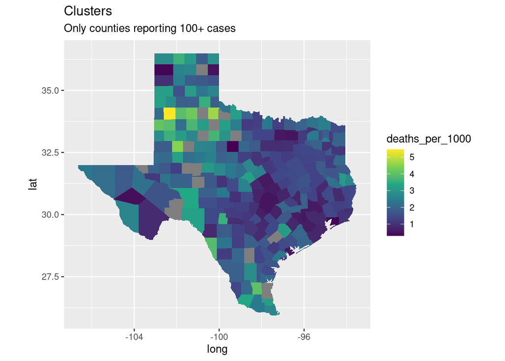

```r
ggplot(counties_TX_clust, aes(long, lat)) +
  geom_polygon(aes(group = group, fill = deaths_per_1000)) +
  coord_quickmap() +
  scale_fill_continuous(type = "viridis") +
  labs(title = "Clusters", subtitle = "Only counties reporting 100+ cases")
```

# Cluster cases_TX with k-means

Since it is unsupervised learning, I do not use the “outcome” variables. The question is: If we find counties with similar demographic composition, then they might exhibit a similar spread of the infection.

The ranges of the variables are different so I scale them to z-scores.

```r
cases_TX_scaled <- cases_TX %>%
  select(
    median_income,
    median_age,
   # total_pop, # you should use density
    poverty,
    commuters_by_public_transportation
  ) %>%
  scale() %>% as_tibble()

summary(cases_TX_scaled)
```

```
##  median_income       median_age          poverty
##  Min.   :-2.1328   Min.   :-2.22811   Min.   :-0.2678
##  1st Qu.:-0.6216   1st Qu.:-0.72101   1st Qu.:-0.2505
##  Median :-0.1423   Median :-0.07878   Median :-0.2235
##  Mean   : 0.0000   Mean   : 0.00000   Mean   : 0.0000
##  3rd Qu.: 0.4644   3rd Qu.: 0.70046   3rd Qu.:-0.1471
##  Max.   : 3.7929   Max.   : 3.13238   Max.   :11.0866
##  commuters_by_public_transportation
##  Min.   :-0.1624
##  1st Qu.:-0.1624
##  Median :-0.1599
##  Mean   : 0.0000
##  3rd Qu.:-0.1501
##  Max.   :11.8901
```

Cluster. I try 4 clusters.

```r
km <- kmeans(cases_TX_scaled, centers = 4)
km
```

```
## K-means clustering with 4 clusters of sizes 46, 96, 95, 3
##
## Cluster means:
##   median_income median_age     poverty commuters_by_public_transportation
## 1     1.5718200 -0.3673191  0.06092152                         0.06456542
## 2    -0.3956768 -0.7524097 -0.03139256                        -0.11859594
## 3    -0.3763701  0.9683496 -0.22824430                        -0.15937135
## 4     0.4788043 -0.9550694  7.29816822                         7.85182628
##
## Clustering vector:
##   [1] 4 4 1 4 2 1 1 2 1 2 1 2 1 2 2 1 1 1 2 2 2 1 2 2 2 1 1 1 1 2 2 1 2 1 1 1 3
##  [38] 2 2 1 2 1 2 2 2 2 2 2 2 1 2 3 3 2 2 2 3 1 2 2 1 2 2 2 2 2 2 1 2 3 1 3 2 2
##  [75] 2 3 2 1 1 2 2 2 2 3 2 3 3 3 3 2 3 3 2 3 2 2 2 2 2 3 2 1 3 3 3 2 2 3 2 3 3
## [112] 1 3 2 3 2 3 2 3 3 1 2 2 1 3 2 2 2 2 2 1 2 2 3 2 2 3 2 3 2 3 3 3 2 3 3 3 3
## [149] 2 3 2 1 3 3 3 2 3 3 3 3 2 3 2 3 1 2 1 2 2 2 3 2 3 3 2 2 3 3 2 1 3 3 3 3 2
## [186] 3 3 3 2 1 3 2 3 3 2 2 3 1 3 3 1 3 2 1 3 3 3 3 1 3 3 1 3 3 3 2 3 3 3 3 3 1
## [223] 3 3 3 2 3 3 3 1 3 3 3 1 3 3 1 3 3 3
##
## Within cluster sum of squares by cluster:
## [1] 88.42524 91.05041 75.83159 51.58488
##  (between_SS / total_SS =  67.9 %)
##
## Available components:
##
## [1] "cluster"      "centers"      "totss"        "withinss"     "tot.withinss"
## [6] "betweenss"    "size"         "iter"         "ifault"
```

look at cluster profiles.

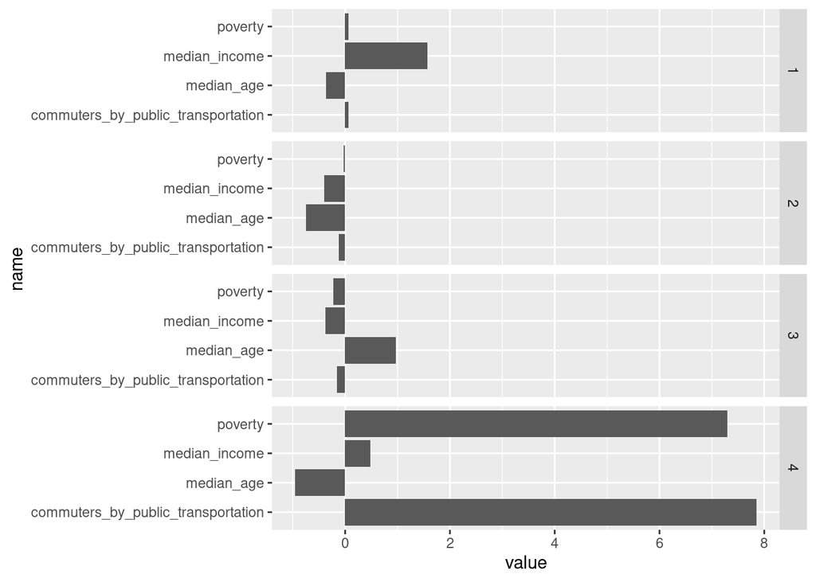

```r
ggplot(pivot_longer(as_tibble(km$centers,  rownames = "cluster"),
  cols = colnames(km$centers)),
  aes(y = name, x = value)) +
  geom_bar(stat = "identity") +
  facet_grid(rows = vars(cluster))
```

Counties for map

```r
counties <- as_tibble(map_data("county"))
counties_TX <- counties %>% dplyr::filter(region == "texas") %>%
  rename(c(county = subregion))
```

make county name match map county names

```r
cases_TX <- cases_TX %>% mutate(county = county_name %>%
    str_to_lower() %>% str_replace('\\s+county\\s*$', ''))

counties_TX_clust <- counties_TX %>% left_join(cases_TX %>%
    add_column(cluster = factor(km$cluster)))
```

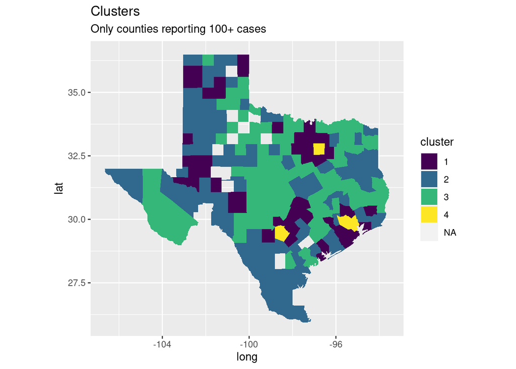

```r
ggplot(counties_TX_clust, aes(long, lat)) +
  geom_polygon(aes(group = group, fill = cluster)) +
  coord_quickmap() +
  scale_fill_viridis_d() +
  labs(title = "Clusters", subtitle = "Only counties reporting 100+ cases")
```

*Note:* You will need to think about how outliers affect the clustering, the appropriate number of clusters, and what the clusters mean for the decision maker.

Check if cases/deaths by 1000 people are different in different clusters:

```r
cases_TX_km <- cases_TX %>% add_column(cluster = factor(km$cluster))

cases_TX_km %>% group_by(cluster) %>% summarize(
  avg_cases = mean(cases_per_1000),
  avg_deaths = mean(deaths_per_1000))
```

```
## # A tibble: 4 x 3
##   cluster avg_cases avg_deaths
##   <fct>       <dbl>      <dbl>
## 1 1            77.2      1.25
## 2 2            91.2      2.16
## 3 3            67.2      1.85
## 4 4            78.6      0.962
```

*Note:* cases and deaths was not used for clustering! The clusters just represent similar demographics.

# Some questions to think about:

- Do the clusters help us with identifying areas with higher risk of severe COVID-19 outbreaks?
- What other variables are important?
- Are the assumptions of k-means appropriate (Euclidean distances)?
- Other clustering algorithms?
- What can you do with the other datasets?